# Test a Perceptual Phenomenon

### Analyzing the Stroop Effect

Perform the analysis in the space below. Remember to follow [the instructions](https://docs.google.com/document/d/1-OkpZLjG_kX9J6LIQ5IltsqMzVWjh36QpnP2RYpVdPU/pub?embedded=True) and review the [project rubric](https://review.udacity.com/#!/rubrics/71/view) before submitting. Once you've completed the analysis and write-up, download this file as a PDF or HTML file, upload that PDF/HTML into the workspace here (click on the orange Jupyter icon in the upper left then Upload), then use the Submit Project button at the bottom of this page. This will create a zip file containing both this .ipynb doc and the PDF/HTML doc that will be submitted for your project.

(1) What is the independent variable? What is the dependent variable?

independent variable: congruent or incongruent condition. dependent variable: Time to complete test.

(2) What is an appropriate set of hypotheses for this task? Specify your null and alternative hypotheses, and clearly define any notation used. Justify your choices.

Null Hypothsis, H0 - No change in time between two reading tasks (congruent or incongruent) Alternate Hypothesis, H1 - incongruent task take more time than congruent. H0: μi ≤ μc (μi - population mean of incongruent values, μc - population mean of congruent values)

H1: μi > μc (μi - population mean of incongruent values, μc - population mean of congruent values)

(3) Report some descriptive statistics regarding this dataset. Include at least one measure of central tendency and at least one measure of variability. The name of the data file is 'stroopdata.csv'.

```python
import math
import pandas as pd
import numpy as np
import seaborn as sns
import matplotlib.pyplot as plt
from scipy.stats import t
%matplotlib inline
```

```python
df = pd.read_csv('stroopdata.csv')

#measure a central tendency of each independent variable
means_con = df['Congruent'].mean()
means_incon = df['Incongruent'].mean()
means_con, means_incon
```

```
(14.051125000000004, 22.01591666666667)
```

```python
med_con = df['Congruent'].median()
med_incon = df['Incongruent'].median()
med_con, med_incon
```

```
(14.3565, 21.0175)
```

```python
std_con = df['Congruent'].std()
std_incon = df['Incongruent'].std()
std_con, std_incon
```

```
(3.559357957645195, 4.797057122469138)
```

```python
var_con = df['Congruent'].var()
var_incon = df['Incongruent'].var()
var_con, var_incon
```

```
(12.669029070652174, 23.011757036231884)
```

(4) Provide one or two visualizations that show the distribution of the sample data. Write one or two sentences noting what you observe about the plot or plots.

```
Text(0.5,1,'Time taken to complete Congruent Test')
```

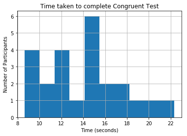

```python
df['Congruent'].hist()
plt.xlabel('Time (seconds)')
plt.ylabel('Number of Participants')
plt.title('Time taken to complete Congruent Test')
```

This histogram shows that largest number of participants (6) took between 14 and 16 seconds to complete the congruent test. This group is in the middle of the distribution indicating a fairly normally distributed sample.

```
Text(0.5,1,'Time taken to complete Incongruent Test')
```

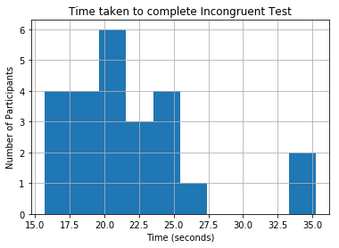

```python
df['Incongruent'].hist()
plt.xlabel('Time (seconds)')
plt.ylabel('Number of Participants')
plt.title('Time taken to complete Incongruent Test')
```

This histogram shows that the largest number of participants (6) took around 20 seconds to complete the incongruent test. Two participants took exceptionally long time to complete the test (more than 33 seconds). They might be outliers.

(5) Now, perform the statistical test and report your results. What is your confidence level or Type I error associated with your test? What is your conclusion regarding the hypotheses you set up? Did the results match up with your expectations? **Hint:** Think about what is being measured on each individual, and what statistic best captures how an individual reacts in each environment.

```python
#Sample size
print(df['Congruent'].size)
print(df['Incongruent'].size)
```

```
24
24
```

```python
#t-critical value for a 95% confidence level and 23 d.f.
t.ppf(.95, 23)
```

```
1.7138715277470473
```

```python
df['Difference'] = df['Congruent'] - df['Incongruent']
std_dif = df['Difference'].std()
std_dif
```

```
4.864826910359056
```

```python
# t-statistic
7.97/(4.8648 / math.sqrt(24))
```

```
8.025996238275749
```

t-critical value ends up being 1.7139, the difference of the means is: 22.02 - 14.05 = 7.97, standard deviation of the differences is 4.8648, t-statistic value is 8.025. the t-statistic is greater than t-critical value, So we can reject the null hypothesis. Which matches up with what we expected, That it takes much less time to do the congruent task than it does to do the incongruent task.